# Reuters – Single-label, Multi-class Classification with Text

Scenario 3: GloVe, pre-trained word embeddings

Rick Scavetta

# Session 4

## Obtain data

```r
c(c(train_data, train_labels), c(test_data, test_labels)) %<-% dataset_reuters(num_words = 10000)

# Map values back onto the lexicon which is stored as a named list. Each item in the list is an integer vector of length one. This number corresponds to the position in the word count list and the name of the vector is the actual word.

dataset_reuters_word_index() %>%
  unlist() %>%                      # produce a vector
  sort() %>%                        # put them in order
  names() -> word_index             # take the ordered names

# Here, we'll get the actual text of the newswire from the integer data. If you read text direclty from a file you don't need to worry aobut this.
train_data %>%
  map(~ word_index[.x]) %>%
  map(~ paste(.x, collapse = " ")) %>%
  unlist() -> texts
```

### Tokenize the data

Let’s vectorize the texts we collected, and prepare a training and validation split. We will merely be using the concepts we introduced earlier in this section.

```r
# We will only consider the top 10,000 words in the dataset
max_words <- 10000

tokenizer <- text_tokenizer(num_words = max_words) %>%
  fit_text_tokenizer(texts)

typeof(tokenizer)
```

```
## [1] "environment"
```

We have now tokenized the text, the first step in our process. Let’s explore:

```r
word_index <- tokenizer$word_index
head(word_index)
```

```
## $yellow
## [1] 5653
##
## $four
## [1] 177
##
## $woods
## [1] 8826
##
## $gaf
## [1] 1942
##
## $cyprus
## [1] 5005
##
## $aggression
## [1] 9703
```

Number of unique tokens:

```r
length(tokenizer$word_index)
```

```
## [1] 9982
```

```r
index_word <- names(sort(unlist(tokenizer$word_index)))

index_word[1:10]
```

```
##  [1] "in"   "of"   "said" "and"  "a"    "mln"  "3"    "for"  "vs"   "dlrs"
```

```r
sequences <- texts_to_sequences(tokenizer, texts)
```

`sequences` contains the vectorized values as a list.

```r
# The vectorized first instance:
sequences[[1]]
```

```
##  [1]   15    2    2    6   42    8  444    3   24  202  262    3 3223  117
## [15]   14  339  178   90   65    5   88    3   18  100    4   18  121   13
## [29]   90   65   83   21  477   25    5   48    1   47    6  883   38  210
## [43]  159    4  151    4   82    9   13   21  156    9   13    5   48    7
## [57] 4569 1022  520    4  252    4  273    9   13   21  132   44    9   13
## [71]   14    6  193 1229   90   65   50   28  210   29   31  126    4  108
## [85]   13   16   10
```

What the text has become:

```r
paste(index_word[sequences[[1]]] ,collapse=" ")
```

```
## [1] "the of of mln loss for plc said at only ended said commonwealth could 1 traders now april 0 a after said from 1985 and from foreign 000 april 0 prices its account year a but in this mln home an states earlier and rise and revs vs 000 its 16 vs 000 a but 3 psbr oils several and shareholders a…
```

From our original text:

```r
texts[[1]]
```

```
## [1] "the of of mln loss for plc said at only ended said commonwealth could 1 traders now april 0 a after said from 1985 and from foreign 000 april 0 prices its account year a but in this mln home an states earlier and rise and revs vs 000 its 16 vs 000 a but 3 psbr oils several and shareholders a…
```

```r
maxlen <- 100                 # We will cut reviews after 100 words

data <- pad_sequences(sequences, maxlen = maxlen)
```

```r
data[1,]
```

```
##   [1]    0    0    0    0    0    0    0    0    0    0    0    0    0   15
##  [15]    2    2    6   42    8  444    3   24  202  262    3 3223  117   14
##  [29]  339  178   90   65    5   88    3   18  100    4   18  121   13   90
##  [43]   65   83   21  477   25    5   48    1   47    6  883   38  210  159
##  [57]    4  151    4   82    9   13   21  156    9   13    5   48    7 4569
##  [71] 1022  520    4  252    4  273    9   13   21  132   44    9   13   14
##  [85]    6  193 1229   90   65   50   28  210   29   31  126    4  108   13
##  [99]   16   10
```

```r
paste(unlist(index_word)[data[1,]] ,collapse=" ")
```

```
## [1] "the of of mln loss for plc said at only ended said commonwealth could 1 traders now april 0 a after said from 1985 and from foreign 000 april 0 prices its account year a but in this mln home an states earlier and rise and revs vs 000 its 16 vs 000 a but 3 psbr oils several and shareholders a…
```

And here, instead of letting the fit function produce a validation set split, we’ll do that manually.

```r
indices <- sample(1:nrow(data))

# training_samples <- nrow(data)/2       # We will be training on 4491 samples
# validation_samples <- nrow(data)/2   # We will be validating on 4491 samples

n <- 7500
training_samples <- n
validation_samples <- 8982-n


training_indices <- indices[1:training_samples]
validation_indices <- indices[(training_samples + 1):
                              (training_samples + validation_samples)]

x_train <- data[training_indices,]

# Prepare the labels
labels <- as.array(train_labels)
y_train <- labels[training_indices]


x_val <- data[validation_indices,]
y_val <- labels[validation_indices]
```

## GloVe word embeddings

The GloVE pretrained word embeddings are derived from the 2014 English Wikipedia. It can be downloaded [here](https://nlp.stanford.edu/projects/glove/). The file to look for is `glove.6B.zip` (822MB). In it you’ll find 100-dimensional embedding vectors for 400,000 words (or non-word tokens).

Download and unzip the file (it will just a be a `txt` file) and place it in the *pretrained* folder.

Here are the commands if you want to do this via the terminal:

```
mkdir pretrained
cd pretrained/
mkdir glove.6B
cd glove.6B
wget "http://nlp.stanford.edu/data/glove.6B.zip"
unzip glove.6B.zip
rm glove.6B.zip
```

### Pre-process the embeddings

We’ll parse the `txt` file to build an index mapping words (as strings) to their vector representation (as number vectors).

```r
glove_dir <- "./pretrained/glove.6B"
lines <- readLines(file.path(glove_dir, "glove.6B.100d.txt"))

lines[1] # Word embeddings in 100 dimensions.
```

```
## [1] "the -0.038194 -0.24487 0.72812 -0.39961 0.083172 0.043953 -0.39141 0.3344 -0.57545 0.087459 0.28787 -0.06731 0.30906 -0.26384 -0.13231 -0.20757 0.33395 -0.33848 -0.31743 -0.48336 0.1464 -0.37304 0.34577 0.052041 0.44946 -0.46971 0.02628 -0.54155 -0.15518 -0.14107 -0.039722 0.28277 0.14393 0.…
```

The word embeddings are contained in strings that contain the word and then 100 numbers separated by a space. We need to get an embedding matrix that we can use

Here we’ll use a nice trick to work with the embeddings by making them into an environment instead of a list.

```r
embeddings_index <- new.env(hash = TRUE, parent = emptyenv())
for (i in 1:length(lines)) {
  line <- lines[[i]]
  values <- strsplit(line, " ")[[1]]
  word <- values[[1]]
  embeddings_index[[word]] <- as.double(values[-1])
}

# length(embeddings_index)
# 400000
```

This results in 400000 word vectors. i.e. the 100-dimensional embedding vectors for 400,000 words.

```r
embeddings_index[["said"]]
```

```
##   [1] -0.1312800 -0.4520000  0.0433990 -0.9979800 -0.2105300 -0.9586800
##   [7] -0.2460900  0.4841300  0.1817800  0.4750000 -0.2230500  0.3006400
##  [13]  0.4349600 -0.3605000  0.2024500 -0.5259400 -0.3470800  0.0075873
##  [19] -1.0497000  0.1867300  0.5736900  0.4381400  0.0986590  0.3877000
##  [25] -0.2258000  0.4191100  0.0436020 -0.7352000 -0.5358300  0.1927600
##  [31] -0.2196100  0.4251500 -0.1908200  0.4718700  0.1882600  0.1335700
##  [37]  0.4183900  1.3138000  0.3567800 -0.3217200 -1.2257000 -0.2663500
##  [43]  0.3671600 -0.2758600 -0.5324600  0.1678600 -0.1125300 -0.9995900
##  [49] -0.6070600 -0.8927100  0.6515600 -0.8878400  0.0492330  0.6711100
##  [55] -0.2755300 -2.4005000 -0.3698900  0.2913600  1.3498000  1.7353000
##  [61]  0.2700000  0.0212990  0.1442200  0.0237840  0.3364300 -0.3547600
##  [67]  1.0921000  1.4845000  0.4943000  0.1568800  0.3467900 -0.5722100
##  [73]  0.1209300 -1.2616000  1.0541000  0.0643350 -0.0027320  0.1903800
##  [79] -1.7643000  0.0550680  1.4737000 -0.4178200 -0.5734200 -0.1212900
##  [85] -1.3169000 -0.7388300  0.1768200 -0.0199910 -0.4917600 -0.5524700
##  [91]  1.0623000 -0.6287900  0.2909800  0.1323800 -0.7041400  0.6712800
##  [97] -0.0854620 -0.3052600 -0.0454950  0.5650900
```

Now we’re ready to build an embedding matrix that we can load into an embedding layer.

It must be a matrix of shape `(max_words, embedding_dim)`, where each entry *i* contains the `embedding_dim`-dimensional vector for the word of index *i* in the reference word index (built during tokenization). Note that index 1 isn’t supposed to stand for any word or token – it’s a placeholder.

```r
embedding_dim <- 100

embedding_matrix <- array(0, c(max_words, embedding_dim))

for (word in names(word_index)) {
  index <- word_index[[word]]
  if (index < max_words) {
    embedding_vector <- embeddings_index[[word]]
    if (!is.null(embedding_vector))
      # Words not found in the embedding index will be all zeros.
      embedding_matrix[index+1,] <- embedding_vector
  }
}
```

## Define a model

We will be using the same model architecture as before:

```r
model <- keras_model_sequential() %>%
  layer_embedding(input_dim = max_words, # 10000 tokens
                  output_dim = embedding_dim, # dimensions in embedding layer
                  input_length = maxlen) %>%  # length of each review set by maxlen
  layer_flatten() %>%
  layer_dense(units = 32, activation = "relu") %>%
  layer_dense(units = 32, activation = "relu") %>%
  layer_dense(units = 46, activation = "softmax")

summary(model)
```

```
## ___________________________________________________________________________
## Layer (type)                     Output Shape                  Param #
## ===========================================================================
## embedding_1 (Embedding)          (None, 100, 100)              1000000
## ___________________________________________________________________________
## flatten_1 (Flatten)              (None, 10000)                 0
## ___________________________________________________________________________
## dense_1 (Dense)                  (None, 32)                    320032
## ___________________________________________________________________________
## dense_2 (Dense)                  (None, 32)                    1056
## ___________________________________________________________________________
## dense_3 (Dense)                  (None, 46)                    1518
## ===========================================================================
## Total params: 1,322,606
## Trainable params: 1,322,606
## Non-trainable params: 0
## ___________________________________________________________________________
```

### Load the GloVe embeddings in the model

The embedding layer has a single weight matrix: a 2D float matrix where each entry *i* is the word vector meant to be associated with index *i*. Simple enough. Load the GloVe matrix you prepared into the embedding layer, the first layer in the model.

```r
get_layer(model, index = 1) %>%
  set_weights(list(embedding_matrix)) %>%
  freeze_weights()
```

Additionally, you’ll freeze the weights of the embedding layer, following the same rationale you’re already familiar with in the context of pretrained convnet features: when parts of a model are pretrained (like your embedding layer) and parts are randomly initialized (like your classifier), the pretrained parts shouldn’t be updated during training, to avoid forgetting what they already know. The large gradient updates triggered by the randomly initialized layers would be disruptive to the already-learned features.

### Train and evaluate

Let’s compile our model and train it:

```r
model %>% compile(
  optimizer = "rmsprop",
  loss = "sparse_categorical_crossentropy",
  metrics = "accuracy"
)

history <- model %>% fit(
  x_train, y_train,
  epochs = 20,
  batch_size = 32,
  validation_data = list(x_val, y_val)
)

save_model_weights_hdf5(model, "pre_trained_glove_model.h5")
```

Plot the performance over time:

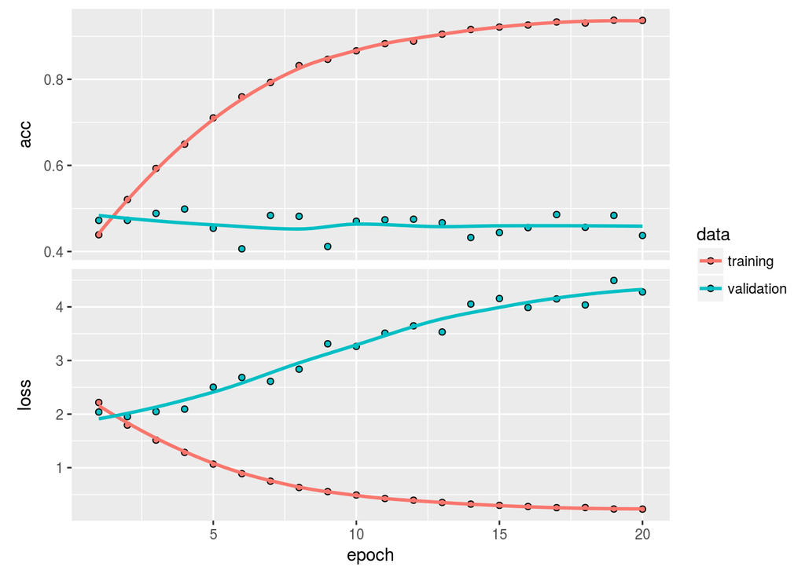

```r
plot(history)
```

We can also try to train the same model without loading the pre-trained word embeddings and without freezing the embedding layer. In that case, we would be learning a task-specific embedding of our input tokens, which is generally more powerful than pre-trained word embeddings when lots of data is available. Let’s try it:

```r
model <- keras_model_sequential() %>%
  layer_embedding(input_dim = max_words, output_dim = embedding_dim,
                  input_length = maxlen) %>%
  layer_flatten() %>%
  layer_dense(units = 32, activation = "relu") %>%
  layer_dense(units = 32, activation = "relu") %>%
  layer_dense(units = 46, activation = "softmax")

model %>% compile(
  optimizer = "rmsprop",
  loss = "sparse_categorical_crossentropy",
  metrics = "accuracy"
)

history <- model %>% fit(
  x_train, y_train,
  epochs = 20
  ,
  batch_size = 32,
  validation_data = list(x_val, y_val)
)
```

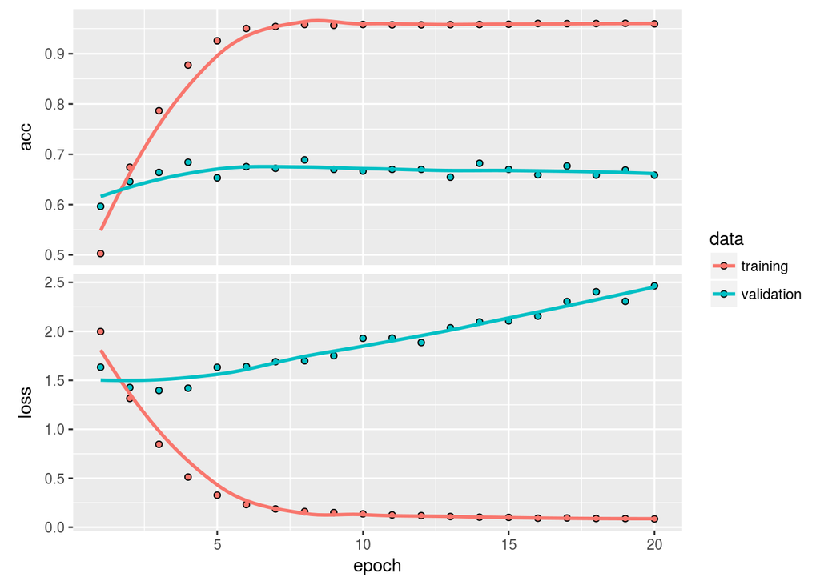

```r
plot(history)
```

## Evaluation

Finally, let’s evaluate the model on the test data. First, we will need to tokenize the test data:

```r
test_data %>%
  # unlist %>%
  map(~ word_index[.x]) %>%
  map(~ paste(.x, collapse = " ")) %>%
  unlist() -> texts
sequences <- texts_to_sequences(tokenizer, texts)
x_test <- pad_sequences(sequences, maxlen = maxlen)
y_test <- as.array(test_labels)
```

And let’s load and evaluate the first model:

```r
model %>%
  load_model_weights_hdf5("pre_trained_glove_model.h5") %>%
  evaluate(x_test, y_test, verbose = 0)
```

```
## $loss
## [1] 4.696431
##
## $acc
## [1] 0.07390917
```

```r
model %>%
  evaluate(x_test, y_test, verbose = 0)
```

```
## $loss
## [1] 4.696431
##
## $acc
## [1] 0.07390917
```